# Perceptions of AI Consciousness

Author

Nykko Vitali

# 1 Some Background

## 1.1 🤔 **Main Question:**

### 1.1.1 *How do Reddit users of the Claude and ChatGPT subreddits perceive the conscious experience of LLMs?*

## 1.2 **Poll Question:**

**Do you think Claude/ChatGPT (any version) has a conscious experience?**

**Note**

**Additional Instructions Given:**  
There’s no universally agreed-upon definition of consciousness.  
Please answer based on your own understanding.

📅 **The poll was run for 7 days in both subreddits.**

🔍 **Let’s take a look.**

## 1.3 ChatGPT Consciousness Poll

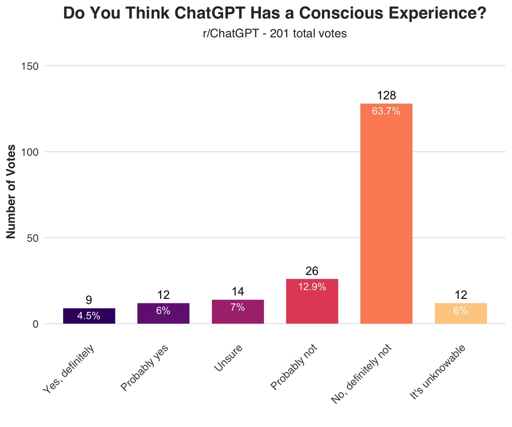

## 1.4 Claude Consciousness Poll

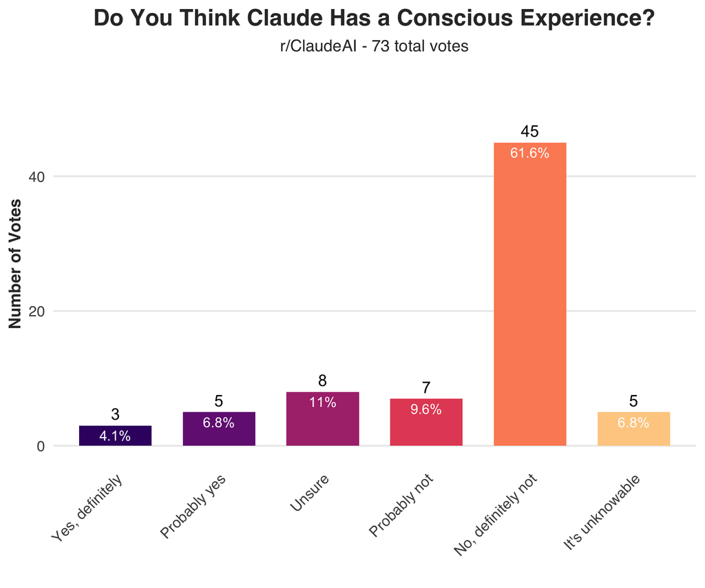

## 1.5 Comparative Analysis

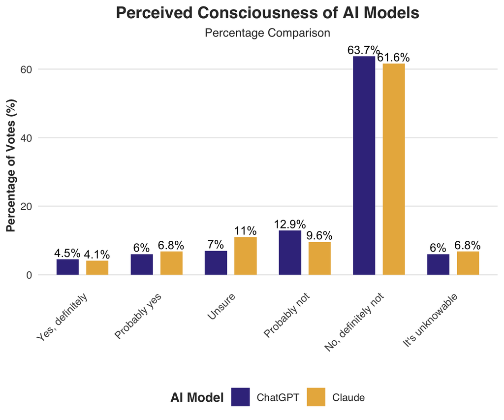

## 1.6 Main Similarities & Differences

- Both models show similar patterns of perceived consciousness:
  - Majority (~62-64%) firmly believe neither model is conscious.
  - Small percentage (~10-11%) believe models have consciousness.
- Subtle differences:
  - Claude users slightly more uncertain (11% vs 7%).
  - ChatGPT has more total votes (201 vs 73).

## 1.7 **Cool. What Do I Take Away From This?**

**Important**

- **Users remain skeptical** about AI consciousness. *But* a non-zero amount report believing these models have an experience, indicating a small but present divergence in opinion.
- **Both communities** (Claude & ChatGPT) show similar beliefs, suggesting that perceptions of AI consciousness are **platform-agnostic** rather than model-specific.
- **Sampling bias** may influence these perceptions, as users engaging in these discussions may already have strong prior opinions on AI capabilities.